# FOREST COVER TYPE PREDICTION

## Goal

In this project, we will attempt to predict the forest cover type (the predominant kind of tree cover) using data obtained from US Forest Service and US Geological Survey.

The study area includes four wilderness areas located in the Roosevelt National Forest of northern Colorado. Each observation is a 30m x 30m patch. We need to predict an integer classification for the forest cover type. The seven types are:

1. Spruce/Fir
2. Lodgepole Pine
3. Ponderosa Pine
4. Cottonwood/Willow
5. Aspen
6. Douglas-fir
7. Krummholz

**Data Fields**

1. Elevation - Elevation in meters
2. Aspect - Aspect in degrees azimuth
3. Slope - Slope in degrees
4. Horizontal_Distance_To_Hydrology - Horz Dist to nearest surface water features
5. Vertical_Distance_To_Hydrology - Vert Dist to nearest surface water features
6. Horizontal_Distance_To_Roadways - Horz Dist to nearest roadway
7. Hillshade_9am (0 to 255 index) - Hillshade index at 9am, summer solstice
8. Hillshade_Noon (0 to 255 index) - Hillshade index at noon, summer solstice
9. Hillshade_3pm (0 to 255 index) - Hillshade index at 3pm, summer solstice
10. Horizontal_Distance_To_Fire_Points - Horz Dist to nearest wildfire ignition points
11. Wilderness_Area (4 binary columns, 0 = absence or 1 = presence) - Wilderness area designation
12. Soil_Type (40 binary columns, 0 = absence or 1 = presence) - Soil Type designation
13. Cover_Type (7 types, integers 1 to 7) - Forest Cover Type designation

*More details about the data can be found [here](https://www.kaggle.com/c/forest-cover-type-prediction/data)*

## Why predicting Forest type?

To prevent species from extinction and help balancing the natural habitat!

As this study includes wild forest areas with minimal human-caused disturbances, we hope that we can forecast the forest's growth trends (ecological processes), identify areas that are affected seriously by climate change or other disasters to timely mitigate the problems.

# Loading Packages

```python
# for data manipulation
import numpy as np # linear algebra
import pandas as pd # data processing, CSV file I/O (e.g. pd.read_csv)

# for visualization
from matplotlib import pyplot as plt
# to include graphs inline within the frontends next to code
import seaborn as sns

# preprocessing functions and evaluation models
from sklearn.preprocessing import OneHotEncoder, MinMaxScaler, StandardScaler
from sklearn.model_selection import train_test_split, cross_val_score, GridSearchCV,RandomizedSearchCV
from sklearn.pipeline import Pipeline
from sklearn.metrics import accuracy_score, confusion_matrix
from sklearn.dummy import DummyClassifier

# machine learning models
from sklearn.linear_model import LogisticRegression
from sklearn.tree import DecisionTreeClassifier
from sklearn.neighbors import KNeighborsClassifier
from sklearn.ensemble import RandomForestClassifier, GradientBoostingClassifier,ExtraTreesClassifier
from xgboost import XGBClassifier
```

# Loading Data

```python
train = pd.read_csv('train_1.csv')
test = pd.read_csv('test_1.csv')
```

# Cleaning and Understanding Data

```python
print("Number of rows and columns in the train dataset are:", train.shape)
```

```
Number of rows and columns in the train dataset are: (15120, 56)
```

```python
#Let's take a look at the data
train.head()
```

|  | Id | Elevation | Aspect | Slope | Horizontal_Distance_To_Hydrology | Vertical_Distance_To_Hydrology | Horizontal_Distance_To_Roadways | Hillshade_9am | Hillshade_Noon | Hillshade_3pm | ... | Soil_Type32 | Soil_Type33 | Soil_Type34 | Soil_Type35 | Soil_Type36 | Soil_Type37 | Soil_Type38 | Soil_Type39 | Soil_Type40 | Cover_Type |
| --- | --- | --- | --- | --- | --- | --- | --- | --- | --- | --- | --- | --- | --- | --- | --- | --- | --- | --- | --- | --- | --- |
| 0 | 1 | 2596 | 51 | 3 | 258 | 0 | 510 | 221 | 232 | 148 | ... | 0 | 0 | 0 | 0 | 0 | 0 | 0 | 0 | 0 | 5 |
| 1 | 2 | 2590 | 56 | 2 | 212 | -6 | 390 | 220 | 235 | 151 | ... | 0 | 0 | 0 | 0 | 0 | 0 | 0 | 0 | 0 | 5 |
| 2 | 3 | 2804 | 139 | 9 | 268 | 65 | 3180 | 234 | 238 | 135 | ... | 0 | 0 | 0 | 0 | 0 | 0 | 0 | 0 | 0 | 2 |
| 3 | 4 | 2785 | 155 | 18 | 242 | 118 | 3090 | 238 | 238 | 122 | ... | 0 | 0 | 0 | 0 | 0 | 0 | 0 | 0 | 0 | 2 |
| 4 | 5 | 2595 | 45 | 2 | 153 | -1 | 391 | 220 | 234 | 150 | ... | 0 | 0 | 0 | 0 | 0 | 0 | 0 | 0 | 0 | 5 |

5 rows × 56 columns

We have a lot of categorical features here. Soil type was coverted to dummy variable for us!

```python
#Get the summary of data (exclude dummmy variables)
train.iloc[:,1:10].describe()
```

|  | Elevation | Aspect | Slope | Horizontal_Distance_To_Hydrology | Vertical_Distance_To_Hydrology | Horizontal_Distance_To_Roadways | Hillshade_9am | Hillshade_Noon | Hillshade_3pm |
| --- | --- | --- | --- | --- | --- | --- | --- | --- | --- |
| count | 15120.000000 | 15120.000000 | 15120.000000 | 15120.000000 | 15120.000000 | 15120.000000 | 15120.000000 | 15120.000000 | 15120.000000 |
| mean | 2749.322553 | 156.676653 | 16.501587 | 227.195701 | 51.076521 | 1714.023214 | 212.704299 | 218.965608 | 135.091997 |
| std | 417.678187 | 110.085801 | 8.453927 | 210.075296 | 61.239406 | 1325.066358 | 30.561287 | 22.801966 | 45.895189 |
| min | 1863.000000 | 0.000000 | 0.000000 | 0.000000 | -146.000000 | 0.000000 | 0.000000 | 99.000000 | 0.000000 |
| 25% | 2376.000000 | 65.000000 | 10.000000 | 67.000000 | 5.000000 | 764.000000 | 196.000000 | 207.000000 | 106.000000 |
| 50% | 2752.000000 | 126.000000 | 15.000000 | 180.000000 | 32.000000 | 1316.000000 | 220.000000 | 223.000000 | 138.000000 |
| 75% | 3104.000000 | 261.000000 | 22.000000 | 330.000000 | 79.000000 | 2270.000000 | 235.000000 | 235.000000 | 167.000000 |
| max | 3849.000000 | 360.000000 | 52.000000 | 1343.000000 | 554.000000 | 6890.000000 | 254.000000 | 254.000000 | 248.000000 |

```python
#check missing values
train.isna().sum()
```

```
Id                                    0
Elevation                             0
Aspect                                0
Slope                                 0
Horizontal_Distance_To_Hydrology      0
Vertical_Distance_To_Hydrology        0
Horizontal_Distance_To_Roadways       0
Hillshade_9am                         0
Hillshade_Noon                        0
Hillshade_3pm                         0
Horizontal_Distance_To_Fire_Points    0
Wilderness_Area1                      0
Wilderness_Area2                      0
Wilderness_Area3                      0
Wilderness_Area4                      0
Soil_Type1                            0
Soil_Type2                            0
Soil_Type3                            0
Soil_Type4                            0
Soil_Type5                            0
Soil_Type6                            0
Soil_Type7                            0
Soil_Type8                            0
Soil_Type9                            0
Soil_Type10                           0
Soil_Type11                           0
Soil_Type12                           0
Soil_Type13                           0
Soil_Type14                           0
Soil_Type15                           0
Soil_Type16                           0
Soil_Type17                           0
Soil_Type18                           0
Soil_Type19                           0
Soil_Type20                           0
Soil_Type21                           0
Soil_Type22                           0
Soil_Type23                           0
Soil_Type24                           0
Soil_Type25                           0
Soil_Type26                           0
Soil_Type27                           0
Soil_Type28                           0
Soil_Type29                           0
Soil_Type30                           0
Soil_Type31                           0
Soil_Type32                           0
Soil_Type33                           0
Soil_Type34                           0
Soil_Type35                           0
Soil_Type36                           0
Soil_Type37                           0
Soil_Type38                           0
Soil_Type39                           0
Soil_Type40                           0
Cover_Type                            0
dtype: int64
```

There is no missing value in this dataset.

### Checking Outliers

```python
def outlier_function(df, col_name):
    ''' this function detects first and third quartile and interquartile range for a given column of a dataframe
    then calculates upper and lower limits to determine outliers conservatively
    returns the number of lower and uper limit and number of outliers respectively
    '''
    first_quartile = np.percentile(np.array(df[col_name].tolist()), 25)
    third_quartile = np.percentile(np.array(df[col_name].tolist()), 75)
    IQR = third_quartile - first_quartile

    upper_limit = third_quartile+(3*IQR)
    lower_limit = first_quartile-(3*IQR)
    outlier_count = 0

    for value in df[col_name].tolist():
        if (value < lower_limit) | (value > upper_limit):
            outlier_count +=1
    return lower_limit, upper_limit, outlier_count
```

```python
# loop through all columns to see if there are any outliers
for i in train.columns:
    if outlier_function(train, i)[2] > 0:
        print("There are {} outliers in {}".format(outlier_function(train, i)[2], i))
```

```
There are 53 outliers in Horizontal_Distance_To_Hydrology
There are 49 outliers in Vertical_Distance_To_Hydrology
There are 3 outliers in Horizontal_Distance_To_Roadways
There are 7 outliers in Hillshade_9am
There are 20 outliers in Hillshade_Noon
There are 132 outliers in Horizontal_Distance_To_Fire_Points
There are 3597 outliers in Wilderness_Area1
There are 499 outliers in Wilderness_Area2
There are 355 outliers in Soil_Type1
There are 623 outliers in Soil_Type2
There are 962 outliers in Soil_Type3
There are 843 outliers in Soil_Type4
There are 165 outliers in Soil_Type5
There are 650 outliers in Soil_Type6
There are 1 outliers in Soil_Type8
There are 10 outliers in Soil_Type9
There are 2142 outliers in Soil_Type10
There are 406 outliers in Soil_Type11
There are 227 outliers in Soil_Type12
There are 476 outliers in Soil_Type13
There are 169 outliers in Soil_Type14
There are 114 outliers in Soil_Type16
There are 612 outliers in Soil_Type17
There are 60 outliers in Soil_Type18
There are 46 outliers in Soil_Type19
There are 139 outliers in Soil_Type20
There are 16 outliers in Soil_Type21
There are 345 outliers in Soil_Type22
There are 757 outliers in Soil_Type23
There are 257 outliers in Soil_Type24
There are 1 outliers in Soil_Type25
There are 54 outliers in Soil_Type26
There are 15 outliers in Soil_Type27
There are 9 outliers in Soil_Type28
There are 1291 outliers in Soil_Type29
There are 725 outliers in Soil_Type30
There are 332 outliers in Soil_Type31
There are 690 outliers in Soil_Type32
There are 616 outliers in Soil_Type33
There are 22 outliers in Soil_Type34
There are 102 outliers in Soil_Type35
There are 10 outliers in Soil_Type36
There are 34 outliers in Soil_Type37
There are 728 outliers in Soil_Type38
There are 657 outliers in Soil_Type39
There are 459 outliers in Soil_Type40
```

We will take closer look to below 4 columns:

- Horizontal_Distance_To_Hydrology
- Vertical_Distance_To_Hydrology
- Horizontal_Distance_To_Roadways
- Horizontal_Distance_To_Fire_Points

We are not going to consider other columns for potential outlier elimination because their data range is already fixed between 0 and 255 (e.g. Hillsahde columns) or they seem like one-hot-encoded columns (e.g. Soil type and Wilderness areas).

Recall the data ranges of those 4 columns:

- Horizontal_Distance_To_Hydrology: 0, 1343
- Vertical_Distance_To_Hydrology: -146, 554
- Horizontal_Distance_To_Roadways: 0, 6890
- Horizaontal_Distance_To_Firepoints: 0, 6993

Horizaontal_Distance_To_Firepoints having the highest number of outliers and widest data range.

Observations from cleaning and understanding data:

- Train dataset has 15120 rows and 56 columns.
- Each column has numeric (integer/float) datatype.
- There are no NA in the dataset.Thus dataset is properly formatted.
- 4 columns had outliers.
- Cover_Type is our label/target column.

```python
trees = train[(train['Horizontal_Distance_To_Fire_Points'] > outlier_function(train, 'Horizontal_Distance_To_Fire_Points')[0]) &
              (train['Horizontal_Distance_To_Fire_Points'] < outlier_function(train, 'Horizontal_Distance_To_Fire_Points')[1])]
trees.shape
```

```
(14988, 56)
```

# Exploratory Data Analysis

Distribution of Trees

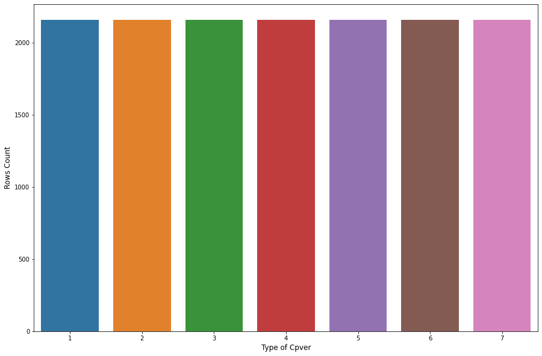

```python
plt.figure(figsize=(15,10))
sns.countplot(train['Cover_Type'])
plt.xlabel("Type of Cpver", fontsize=12)
plt.ylabel("Rows Count", fontsize=12)
plt.show()
```

Distribution of trees shows perfect uniform distribution.

Here are the 7 types of the trees, numbered from 1 to 7 in the Cover_Type column:

1) Spruce/Fir

2) Lodgepole Pine

3) Ponderosa Pine

4) Cottonwood/Willow

5) Aspen

6) Douglas-fir

7) Krummholz

Distribution and relationship of continuous variables (Elevation, Aspect, Slope, Distance and Hillsahde columns)

[output not shown]

[output cut: 114 more lines]

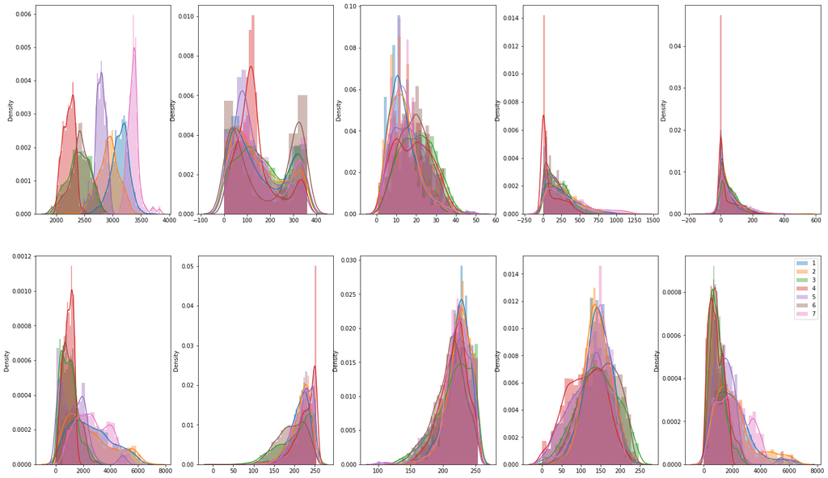

```python
fig, axes = plt.subplots(nrows = 2,ncols = 5,figsize = (25,15))
g= sns.FacetGrid(train, hue='Cover_Type',height=5)
(g.map(sns.distplot,train.columns[1],ax=axes[0][0]))
(g.map(sns.distplot, train.columns[2],ax=axes[0][1]))
(g.map(sns.distplot, train.columns[3],ax=axes[0][2]))
(g.map(sns.distplot, train.columns[4],ax=axes[0][3]))
(g.map(sns.distplot, train.columns[5],ax=axes[0][4]))
(g.map(sns.distplot, train.columns[6],ax=axes[1][0]))
(g.map(sns.distplot, train.columns[7],ax=axes[1][1]))
(g.map(sns.distplot, train.columns[8],ax=axes[1][2]))
(g.map(sns.distplot, train.columns[9],ax=axes[1][3]))
(g.map(sns.distplot, train.columns[10],ax=axes[1][4]))
plt.close(2)
plt.legend()
```

Looking at distribution plots above, it is observed that distribution of numerical variables is not normal. Some of them are right skewed and some of them are left skewed. Distribution of Aspects seems like binary.

In conclusion, we have to scale our numerical variables before they go in model.

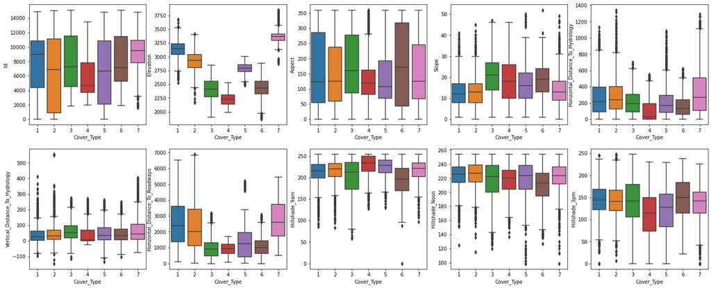

```python
size=10
fig, axes = plt.subplots(nrows = 2,ncols = 5,figsize = (25,10))
for i in range(0,size):
    row = i // 5
    col = i % 5
    ax_curr = axes[row, col]
    sns.boxplot(x="Cover_Type", y=train.columns[i], data=train,ax=ax_curr);
```

Observations:

- Forest "Cover_Type" 1 and 7 have higher "Elevation" than others while 4 has lowest among the all.
- All Forest "Cover_Type" are spreded out in "Aspect".
- Forest Cover Type 1, 2 and 7 have higher Horizontal_Distance_To_Roadways.
- There is not much variation in distribution of Forest Cover Type for each of the other features.
- Other features have almost same level of distribution of Forest Cover Types.

### How Cover types are distributed among Soil types and widerness areas?

```python
#Convert dummy features back to categorical
x = train.iloc[:,15:55]
y = train.iloc[:,11:15]
y = pd.DataFrame(y)
x = pd.DataFrame(x)
s2 = pd.Series(x.columns[np.where(x!=0)[1]])
s3 = pd.Series(y.columns[np.where(y!=0)[1]])
train['soil_type'] = s2
train['Wilderness_Area'] = s3
train.head()
```

|  | Id | Elevation | Aspect | Slope | Horizontal_Distance_To_Hydrology | Vertical_Distance_To_Hydrology | Horizontal_Distance_To_Roadways | Hillshade_9am | Hillshade_Noon | Hillshade_3pm | ... | Soil_Type34 | Soil_Type35 | Soil_Type36 | Soil_Type37 | Soil_Type38 | Soil_Type39 | Soil_Type40 | Cover_Type | soil_type | Wilderness_Area |
| --- | --- | --- | --- | --- | --- | --- | --- | --- | --- | --- | --- | --- | --- | --- | --- | --- | --- | --- | --- | --- | --- |
| 0 | 1 | 2596 | 51 | 3 | 258 | 0 | 510 | 221 | 232 | 148 | ... | 0 | 0 | 0 | 0 | 0 | 0 | 0 | 5 | Soil_Type29 | Wilderness_Area1 |
| 1 | 2 | 2590 | 56 | 2 | 212 | -6 | 390 | 220 | 235 | 151 | ... | 0 | 0 | 0 | 0 | 0 | 0 | 0 | 5 | Soil_Type29 | Wilderness_Area1 |
| 2 | 3 | 2804 | 139 | 9 | 268 | 65 | 3180 | 234 | 238 | 135 | ... | 0 | 0 | 0 | 0 | 0 | 0 | 0 | 2 | Soil_Type12 | Wilderness_Area1 |
| 3 | 4 | 2785 | 155 | 18 | 242 | 118 | 3090 | 238 | 238 | 122 | ... | 0 | 0 | 0 | 0 | 0 | 0 | 0 | 2 | Soil_Type30 | Wilderness_Area1 |
| 4 | 5 | 2595 | 45 | 2 | 153 | -1 | 391 | 220 | 234 | 150 | ... | 0 | 0 | 0 | 0 | 0 | 0 | 0 | 5 | Soil_Type29 | Wilderness_Area1 |

5 rows × 58 columns

```python
# Create a new dataset exluding dummies variable for Mutivariate EDA
df_viz = train.iloc[:, 0:15]
df_viz = df_viz.drop(['Wilderness_Area1', 'Wilderness_Area2', 'Wilderness_Area3',
                      'Wilderness_Area4'], axis = 1)
df_viz.head()
```

|  | Id | Elevation | Aspect | Slope | Horizontal_Distance_To_Hydrology | Vertical_Distance_To_Hydrology | Horizontal_Distance_To_Roadways | Hillshade_9am | Hillshade_Noon | Hillshade_3pm | Horizontal_Distance_To_Fire_Points |
| --- | --- | --- | --- | --- | --- | --- | --- | --- | --- | --- | --- |
| 0 | 1 | 2596 | 51 | 3 | 258 | 0 | 510 | 221 | 232 | 148 | 6279 |
| 1 | 2 | 2590 | 56 | 2 | 212 | -6 | 390 | 220 | 235 | 151 | 6225 |
| 2 | 3 | 2804 | 139 | 9 | 268 | 65 | 3180 | 234 | 238 | 135 | 6121 |
| 3 | 4 | 2785 | 155 | 18 | 242 | 118 | 3090 | 238 | 238 | 122 | 6211 |
| 4 | 5 | 2595 | 45 | 2 | 153 | -1 | 391 | 220 | 234 | 150 | 6172 |

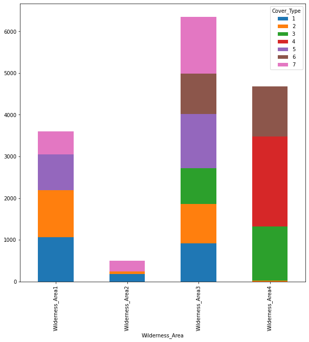

```python
plt.figure(figsize=(15,10))
pd.crosstab(train.Wilderness_Area, train.Cover_Type).plot.bar(figsize=(10,10),stacked = True)
```

Observations:

- Wildnerss Area 2 is very rare compared to other types and is observed only in Cover Type 1 and 7 mainly.
- All Forest Cover Type 4 have Wildnerss Area 4 only
- Wildneress Area 4 is mainly obeserved in Cover Type 3, 4 and 6.
- Wildnerss Area 3 is observed in all Cover Types except cover type 4.

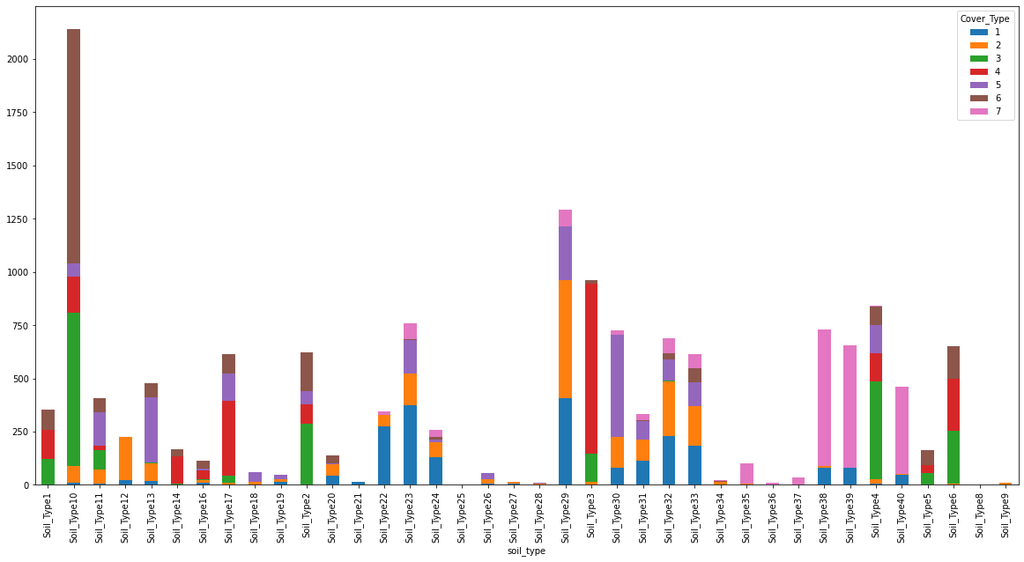

```python
#plt.figure(figsize=(30,30))
pd.crosstab(train.soil_type, train.Cover_Type).plot.bar(figsize=(20,10),stacked = True)
```

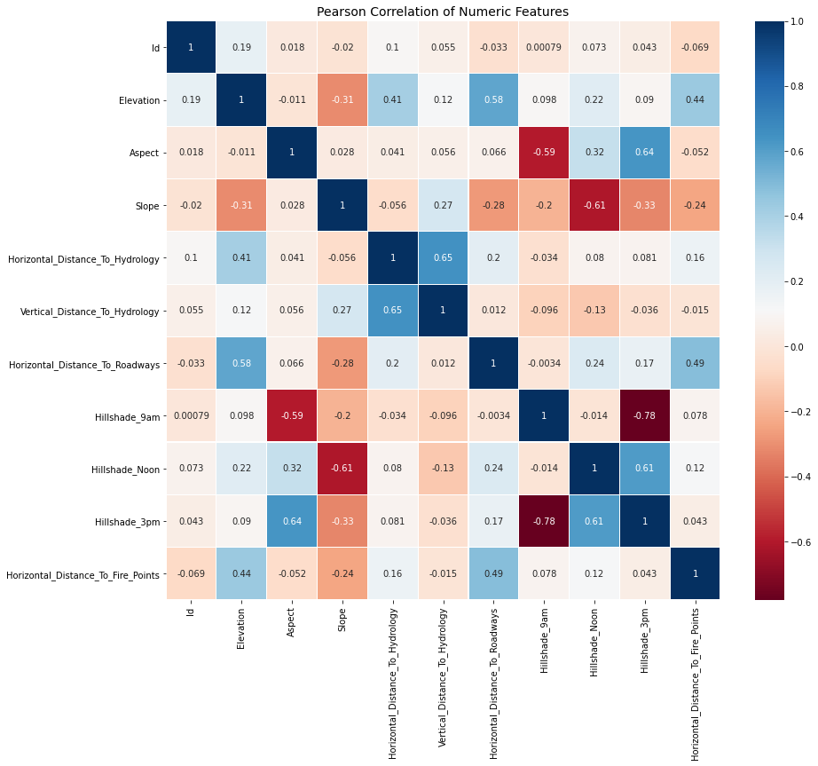

```python
corr = df_viz.corr()

# plot the heatmap
plt.figure(figsize=(14,12))
colormap = plt.cm.RdBu
sns.heatmap(corr,linewidths=0.1,
            square=False, cmap=colormap, linecolor='white', annot=True)
plt.title('Pearson Correlation of Numeric Features', size=14)
```

There are some correlation pairs with strong negative and positive correlations. Please look at the graph, the darker the color, more the correlation

# Feature Engineering

- Most of the time, the features provided don't give us enough values to feed into the models (certain types of data are very hard to measure). Therefore, feature engineering is very powerful to make sure we get the most valuable data out of the original dataset.
- The following added features were created using this [resource](https://nbviewer.jupyter.org/github/aguschin/kaggle/blob/master/forestCoverType_featuresEngineering.ipynb)

```python
def add_feature(data):
    data['Ele_minus_VDtHyd'] = data.Elevation-data.Vertical_Distance_To_Hydrology
    data['Ele_plus_VDtHyd'] = data.Elevation+data.Vertical_Distance_To_Hydrology
    data['Distanse_to_Hydrolody'] = (data['Horizontal_Distance_To_Hydrology']**2+data['Vertical_Distance_To_Hydrology']**2)**0.5
    data['Hydro_plus_Fire'] = data['Horizontal_Distance_To_Hydrology']+data['Horizontal_Distance_To_Fire_Points']
    data['Hydro_minus_Fire'] = data['Horizontal_Distance_To_Hydrology']-data['Horizontal_Distance_To_Fire_Points']
    data['Hydro_plus_Road'] = data['Horizontal_Distance_To_Hydrology']+data['Horizontal_Distance_To_Roadways']
    data['Hydro_minus_Road'] = data['Horizontal_Distance_To_Hydrology']-data['Horizontal_Distance_To_Roadways']
    data['Fire_plus_Road'] = data['Horizontal_Distance_To_Fire_Points']+data['Horizontal_Distance_To_Roadways']
    data['Fire_minus_Road'] = data['Horizontal_Distance_To_Fire_Points']-data['Horizontal_Distance_To_Roadways']
    return data
```

```python
train=trees
train = add_feature(train)
test = add_feature(test)
```

[output not shown]

```python
X_train = train.drop(['Id','Cover_Type'], axis = 1)
y_train = train.Cover_Type
X_test = test.drop(['Id'], axis = 1)
```

# Machine Learning Models' performance summary

## Compare models

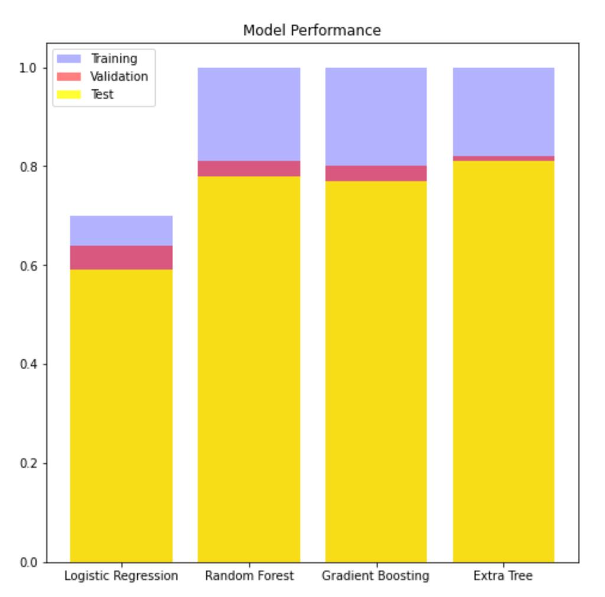

**All models perform worse on unseen data but the gap is so close for Extra Tree model. This is also the model with the highest accuracy rate.**

## Impact of Feature Engineering

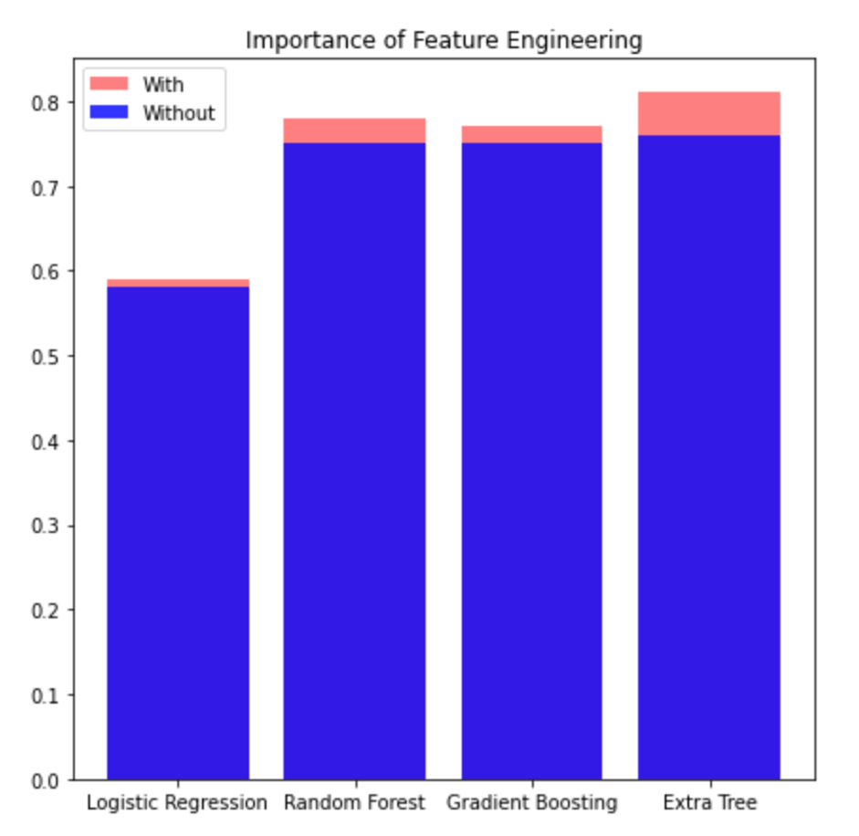

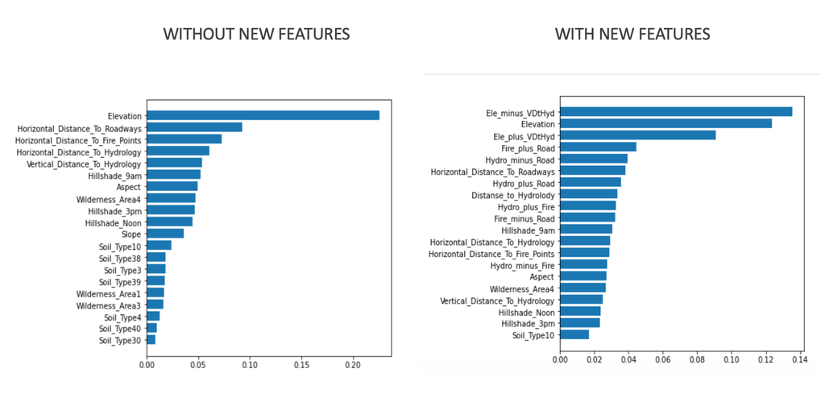

**All models better with new features. The new features are among the most important ones in making prediction.**

# The details process of training the models can be found below

### Logistic regression

- We choose Logistic Regression as our first model because it's simple to use and has the highest interpretability.
- We scale the data first using MinMaxScaler() before feeding into logistic regression model
- Grid search is performed to decide if any regularization is needed (since we have a lot of features so far)

```python
%%time

lr_pipe = Pipeline(
    steps = [
        ('scaler', MinMaxScaler()),
        ('classifier', LogisticRegression(solver='lbfgs', n_jobs=-1))
    ]
)

lr_param_grid = {
    'classifier__C': [1, 10, 100,1000],
}


np.random.seed(1)
grid_search = GridSearchCV(lr_pipe, lr_param_grid, cv=5, refit='True')
grid_search.fit(X_train, y_train)

print('The highest score:',grid_search.best_score_)
print('The best parameter:',grid_search.best_params_)
```

```
The highest score: 0.6414523485014924
The best parameter: {'classifier__C': 1000}
CPU times: user 3.52 s, sys: 626 ms, total: 4.15 s
Wall time: 29.2 s
```

The result is not very impressive, which had been expected from such a simple model. After 5 cross validation, the average result is 0.64 using regularization = 1000.

### Random Forest

- Decision Tree is also a very good model that we want to try due to high interpretability. However, decision tree tends to be very overfitting and perform poorly in new data because of its poor generalization.
- With that being said, other type of tree-based models such as random forest, gradient boosting and extra-tree are used to overcome the challage.

```python
%%time

rf_pipe = Pipeline(
    steps = [
        ('classifier', RandomForestClassifier(n_estimators=500))
    ]
)

param_grid = {
       'classifier__min_samples_leaf': [1,4,7],
    'classifier__max_depth': [34,38,32],
}

np.random.seed(1)
rf_grid_search = GridSearchCV(rf_pipe, param_grid, cv=5, refit='True', n_jobs=-1)
rf_grid_search.fit(X_train, y_train)

print('The highest score:',rf_grid_search.best_score_)
print('The best parameter:',rf_grid_search.best_params_)
```

[output not shown]

```python
#Look at the most important features
rf = rf_grid_search.best_estimator_.steps[0][1]
feat_imp = rf.feature_importances_
feat_imp_df = pd.DataFrame({
    'feature':X_train.columns,
    'feat_imp':feat_imp
})

feat_imp_df.sort_values(by='feat_imp', ascending=False).head(10)
```

|  | feature | feat_imp |
| --- | --- | --- |
| 54 | Ele_minus_VDtHyd | 0.127218 |
| 0 | Elevation | 0.116005 |
| 55 | Ele_plus_VDtHyd | 0.090794 |
| 61 | Fire_plus_Road | 0.045458 |
| 5 | Horizontal_Distance_To_Roadways | 0.039524 |
| 60 | Hydro_minus_Road | 0.039214 |
| 59 | Hydro_plus_Road | 0.036184 |
| 56 | Distanse_to_Hydrolody | 0.035030 |
| 57 | Hydro_plus_Fire | 0.033433 |
| 62 | Fire_minus_Road | 0.033256 |

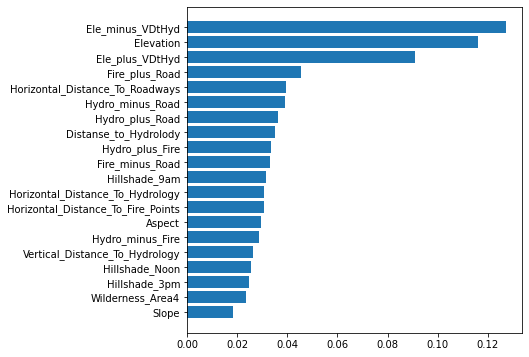

```python
#Visualize the most important features
sorted_feat_imp_df = feat_imp_df.sort_values(by='feat_imp', ascending=True)
plt.figure(figsize=[6,6])
plt.barh(sorted_feat_imp_df.feature[-20:], sorted_feat_imp_df.feat_imp[-20:])
plt.show()
```

### Gradient Boosting

```python
%%time

xgd_pipe = Pipeline(
    steps = [
        ('classifier', XGBClassifier(n_estimators=50, subsample=0.5))
    ]
)

param_grid = {
    'classifier__learning_rate' : [0.45],
    'classifier__min_samples_split' : [8, 16, 32],
    'classifier__min_samples_leaf' : [2],
    'classifier__max_depth': [15]

}

np.random.seed(1)
xgd_grid_search = GridSearchCV(xgd_pipe, param_grid, cv=5,
                              refit='True', verbose = 10, n_jobs=-1)
xgd_grid_search.fit(X_train, y_train)

print(xgd_grid_search.best_score_)
print(xgd_grid_search.best_params_)
```

```
Fitting 5 folds for each of 3 candidates, totalling 15 fits
```

```
[Parallel(n_jobs=-1)]: Using backend LokyBackend with 4 concurrent workers.
[Parallel(n_jobs=-1)]: Done   5 tasks      | elapsed:  2.0min
[Parallel(n_jobs=-1)]: Done  10 out of  15 | elapsed:  3.0min remaining:  1.5min
[Parallel(n_jobs=-1)]: Done  12 out of  15 | elapsed:  3.0min remaining:   44.8s
[Parallel(n_jobs=-1)]: Done  15 out of  15 | elapsed:  3.7min finished
```

```
[11:20:40] WARNING: /Users/travis/build/dmlc/xgboost/src/learner.cc:516:
Parameters: { min_samples_leaf, min_samples_split } might not be used.

  This may not be accurate due to some parameters are only used in language bindings but
  passed down to XGBoost core.  Or some parameters are not used but slip through this
  verification. Please open an issue if you find above cases.


0.799310072803513
{'classifier__learning_rate': 0.45, 'classifier__max_depth': 15, 'classifier__min_samples_leaf': 2, 'classifier__min_samples_split': 8}
CPU times: user 1min 4s, sys: 430 ms, total: 1min 5s
Wall time: 4min 2s
```

```python
xgd_model = xgd_grid_search.best_estimator_

cv_score = cross_val_score(xgd_model, X_train, y_train, cv = 5)
print(cv_score)
print("Accuracy: %0.2f (+/- %0.2f)" % (cv_score.mean(), cv_score.std() * 2))
```

[output not shown]

### ExtraTree Random Forest

```python
xrf_pipe = Pipeline(
    steps = [
        ('classifier', ExtraTreesClassifier(n_estimators=500,random_state=0, criterion = 'entropy'))
    ]
)


xrf_param_grid = {
    'classifier__min_samples_leaf': [1,4,7],
    'classifier__max_depth': [34,38,32],
}

np.random.seed(1)
xrf_grid_search = GridSearchCV(xrf_pipe, xrf_param_grid, cv=5, refit='True', n_jobs=-1)
xrf_grid_search.fit(X_train, y_train)

print(xrf_grid_search.best_score_)
print(xrf_grid_search.best_params_)
```

```
0.8250644239970457
{'classifier__max_depth': 38, 'classifier__min_samples_leaf': 1}
```

```python
final_model = xrf_grid_search.best_estimator_.steps[0][1]
final_model.fit(X_train, y_train)
```

```
ExtraTreesClassifier(criterion='entropy', max_depth=38, n_estimators=500,
                     random_state=0)
```

```python
y_pred = final_model.predict(X_test)
```

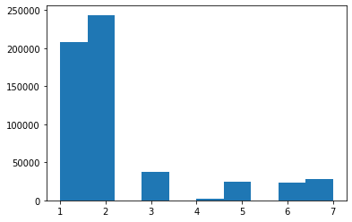

```python
plt.hist(y_pred)
plt.show()
```